# PLS 900 Midterm

Nicolas Bichay

March 15, 2019

```r
setwd('/Users/nickbichay/Desktop/ /aPLS 900/Midterm/')


library(igraph)
library(countrycode)
library(ggplot2)
library(stargazer)
```

# Part One: Structuring Network Data

First, I clean the data and utilize a loop to create the nine sociomatrices by decade, keeping only the top 120 exporters. I store the matrices in a list called ‘mats.’

```r
##### import data

data <- read.csv('Dyadic_COW_4.0.csv', header=TRUE, stringsAsFactors=FALSE)

# -9 = missing values
data <- data[data$flow1 >= 0 & data$flow2 >= 0,]


##### Slice data by decade

mats <- list()
decades <- c(1920, 1930, 1940, 1950, 1960, 1970, 1980, 1990, 2000)

for(i in decades) {

# slice data by decade
data_i <- data[data$year %in% seq(i, (i+9)), c(1,2,3,6,7)]

print(i)
mean(data_i$flow2)

data_i <- aggregate(cbind(flow1=data_i$flow1, flow2=data_i$flow2), by=list(ccode1=(data_i$ccode1), ccode2=(data_i$ccode2)), FUN=mean)


# remove duplicate dyads

data_i$id <- apply(cbind(data_i$ccode1, data_i$ccode2), 1, function(x) paste(sort(x), collapse='+'))


data_i <- aggregate(cbind(flow1 = data_i$flow1, flow2 = data_i$flow2), by=list(id = data_i$id), FUN=sum)

data_i$ccode1 <- do.call(rbind, strsplit(data_i$id, split='+', fixed=TRUE))[,1]
data_i$ccode2 <- do.call(rbind, strsplit(data_i$id, split='+', fixed=TRUE))[,2]


# keep only top 120 by exports
totals <- aggregate(cbind(exports=data_i$flow2), by=list(ccode1=(data_i$ccode1)), FUN=sum)
totals <- totals[order(-totals$exports),]
top120 <- totals$ccode1[1:120]

data_i <- data_i[(data_i$ccode1 %in% top120),]


actors <- unique(c(data_i$ccode1, data_i$ccode2))

n = length(actors)
mat_i <- matrix(0, nrow=n, ncol=n, dimnames=list(actors,actors))
diag(mat_i) = NA


for(j in 1:nrow(data_i)){
    rowActor = as.character(data_i$ccode1[j])
    colActor = as.character(data_i$ccode2[j])
    mat_i[rowActor, colActor]  <- data_i$flow2[j]
    mat_i[colActor, rowActor]  <- data_i$flow1[j]
    }

mats[[i]] <- mat_i

}
```

```
## [1] 1920
## [1] 1930
## [1] 1940
## [1] 1950
## [1] 1960
## [1] 1970
## [1] 1980
## [1] 1990
## [1] 2000
```

```r
# remove null lists (in the between years)
mats[sapply(mats, is.null)] <- NULL
```

# Part Two: Visualizing Network Data

Next I create graphs from the 9 sociomatrices. Edge sizes are based on volume of trade, while node sizes are based on eigenvector centrality. I use eigenvector centrality as countries’ trade with other big traders seems a more important indicator of influence in the global trade market than simply trade connectedness (it also looked the best). Nodes are colored by continent.

```r
##### graph objects

#### 1920

g_1920 = graph_from_adjacency_matrix(mats[[1]], mode='directed', weighted=TRUE, diag=FALSE)

e_1920 <- eigen_centrality(g_1920)$'vector'
V(g_1920)$size <- e_1920*35

width_1920 <- log(E(g_1920)$weight)/40

V(g_1920)$color <- countrycode(attributes(V(g_1920))$names, origin='cown', destination='continent')

V(g_1920)$color=gsub("Americas","green",V(g_1920)$color)
V(g_1920)$color=gsub("Asia","red",V(g_1920)$color)
V(g_1920)$color=gsub("Europe","blue",V(g_1920)$color)
V(g_1920)$color=gsub("Oceania","yellow",V(g_1920)$color)
V(g_1920)$color=gsub("Africa","purple",V(g_1920)$color)

# two NAs which are in Europe
V(g_1920)$color[is.na(V(g_1920)$color)] <- "blue"



#### 1930

g_1930 = graph_from_adjacency_matrix(mats[[2]], mode='directed', weighted=TRUE, diag=FALSE)


e_1930 <- eigen_centrality(g_1930)$'vector'
V(g_1930)$size <- e_1930*30

width_1930 <- E(g_1930)$weight/400

V(g_1930)$color <- countrycode(attributes(V(g_1930))$names, origin='cown', destination='continent')

V(g_1930)$color=gsub("Americas","green",V(g_1930)$color)
V(g_1930)$color=gsub("Asia","red",V(g_1930)$color)
V(g_1930)$color=gsub("Europe","blue",V(g_1930)$color)
V(g_1930)$color=gsub("Oceania","yellow",V(g_1930)$color)
V(g_1930)$color=gsub("Africa","purple",V(g_1930)$color)

# two NAs which are in Europe
V(g_1930)$color[is.na(V(g_1930)$color)] <- "blue"



#### 1940s

g_1940 = graph_from_adjacency_matrix(mats[[3]], mode='directed', weighted=TRUE, diag=FALSE)


e_1940 <- eigen_centrality(g_1940)$'vector'
V(g_1940)$size <- e_1940*30

width_1940 <- log(E(g_1940)$weight)/60

V(g_1940)$color <- countrycode(attributes(V(g_1940))$names, origin='cown', destination='continent')

V(g_1940)$color=gsub("Americas","green",V(g_1940)$color)
V(g_1940)$color=gsub("Asia","red",V(g_1940)$color)
V(g_1940)$color=gsub("Europe","blue",V(g_1940)$color)
V(g_1940)$color=gsub("Oceania","yellow",V(g_1940)$color)
V(g_1940)$color=gsub("Africa","purple",V(g_1940)$color)

# two NAs which are in Europe
V(g_1940)$color[is.na(V(g_1940)$color)] <- "blue"



#### 1950

g_1950 = graph_from_adjacency_matrix(mats[[4]], mode='directed', weighted=TRUE, diag=FALSE)


e_1950 <- eigen_centrality(g_1950)$'vector'
V(g_1950)$size <- e_1950*30

width_1950 <- log(E(g_1950)$weight)/80

V(g_1950)$color <- countrycode(attributes(V(g_1950))$names, origin='cown', destination='continent')

V(g_1950)$color=gsub("Americas","green",V(g_1950)$color)
V(g_1950)$color=gsub("Asia","red",V(g_1950)$color)
V(g_1950)$color=gsub("Europe","blue",V(g_1950)$color)
V(g_1950)$color=gsub("Oceania","yellow",V(g_1950)$color)
V(g_1950)$color=gsub("Africa","purple",V(g_1950)$color)

# two NAs which are in Europe
V(g_1950)$color[is.na(V(g_1950)$color)] <- "blue"



#### 1960

g_1960 = graph_from_adjacency_matrix(mats[[5]], mode='directed', weighted=TRUE, diag=FALSE)


e_1960 <- eigen_centrality(g_1960)$'vector'
V(g_1960)$size <- e_1960*30

width_1960 <- log(E(g_1960)$weight)/80

V(g_1960)$color <- countrycode(attributes(V(g_1960))$names, origin='cown', destination='continent')

V(g_1960)$color=gsub("Americas","green",V(g_1960)$color)
V(g_1960)$color=gsub("Asia","red",V(g_1960)$color)
V(g_1960)$color=gsub("Europe","blue",V(g_1960)$color)
V(g_1960)$color=gsub("Oceania","yellow",V(g_1960)$color)
V(g_1960)$color=gsub("Africa","purple",V(g_1960)$color)

# two NAs which are in Europe
V(g_1960)$color[is.na(V(g_1960)$color)] <- "blue"



#### 1970

g_1970 = graph_from_adjacency_matrix(mats[[6]], mode='directed', weighted=TRUE, diag=FALSE)


e_1970 <- eigen_centrality(g_1970)$'vector'
V(g_1970)$size <- e_1970*45

width_1970 <- log(E(g_1970)$weight)/160

V(g_1970)$color <- countrycode(attributes(V(g_1970))$names, origin='cown', destination='continent')

V(g_1970)$color=gsub("Americas","green",V(g_1970)$color)
V(g_1970)$color=gsub("Asia","red",V(g_1970)$color)
V(g_1970)$color=gsub("Europe","blue",V(g_1970)$color)
V(g_1970)$color=gsub("Oceania","yellow",V(g_1970)$color)
V(g_1970)$color=gsub("Africa","purple",V(g_1970)$color)

# two NAs which are in Europe
V(g_1970)$color[is.na(V(g_1970)$color)] <- "blue"



#### 1980

g_1980 = graph_from_adjacency_matrix(mats[[7]], mode='directed', weighted=TRUE, diag=FALSE)

e_1980 <- eigen_centrality(g_1980)$'vector'
V(g_1980)$size <- e_1980*50

width_1980 <- log(E(g_1980)$weight)/300

V(g_1980)$color <- countrycode(attributes(V(g_1980))$names, origin='cown', destination='continent')

V(g_1980)$color=gsub("Americas","green",V(g_1980)$color)
V(g_1980)$color=gsub("Asia","red",V(g_1980)$color)
V(g_1980)$color=gsub("Europe","blue",V(g_1980)$color)
V(g_1980)$color=gsub("Oceania","yellow",V(g_1980)$color)
V(g_1980)$color=gsub("Africa","purple",V(g_1980)$color)

# two NAs which are in Europe
V(g_1980)$color[is.na(V(g_1980)$color)] <- "blue"



#### 1990

g_1990 = graph_from_adjacency_matrix(mats[[8]], mode='directed', weighted=TRUE, diag=FALSE)

e_1990 <- eigen_centrality(g_1990)$'vector'
V(g_1990)$size <- e_1990*50

width_1990 <- log(E(g_1990)$weight)/600

V(g_1990)$color <- countrycode(attributes(V(g_1990))$names, origin='cown', destination='continent')

V(g_1990)$color=gsub("Americas","green",V(g_1990)$color)
V(g_1990)$color=gsub("Asia","red",V(g_1990)$color)
V(g_1990)$color=gsub("Europe","blue",V(g_1990)$color)
V(g_1990)$color=gsub("Oceania","yellow",V(g_1990)$color)
V(g_1990)$color=gsub("Africa","purple",V(g_1990)$color)

# two NAs which are in Europe
V(g_1990)$color[is.na(V(g_1990)$color)] <- "blue"



#### 2000

g_2000 = graph_from_adjacency_matrix(mats[[9]], mode='directed', weighted=TRUE, diag=FALSE)

e_2000 <- eigen_centrality(g_2000)$'vector'
V(g_2000)$size <- e_2000*50

width_2000 <- log(E(g_2000)$weight)/700

V(g_2000)$color <- countrycode(attributes(V(g_2000))$names, origin='cown', destination='continent')

V(g_2000)$color=gsub("Americas","green",V(g_2000)$color)
V(g_2000)$color=gsub("Asia","red",V(g_2000)$color)
V(g_2000)$color=gsub("Europe","blue",V(g_2000)$color)
V(g_2000)$color=gsub("Oceania","yellow",V(g_2000)$color)
V(g_2000)$color=gsub("Africa","purple",V(g_2000)$color)

# two NAs which are in Europe
V(g_2000)$color[is.na(V(g_2000)$color)] <- "blue"
```

And I place the plots in one figure with a legend of colors

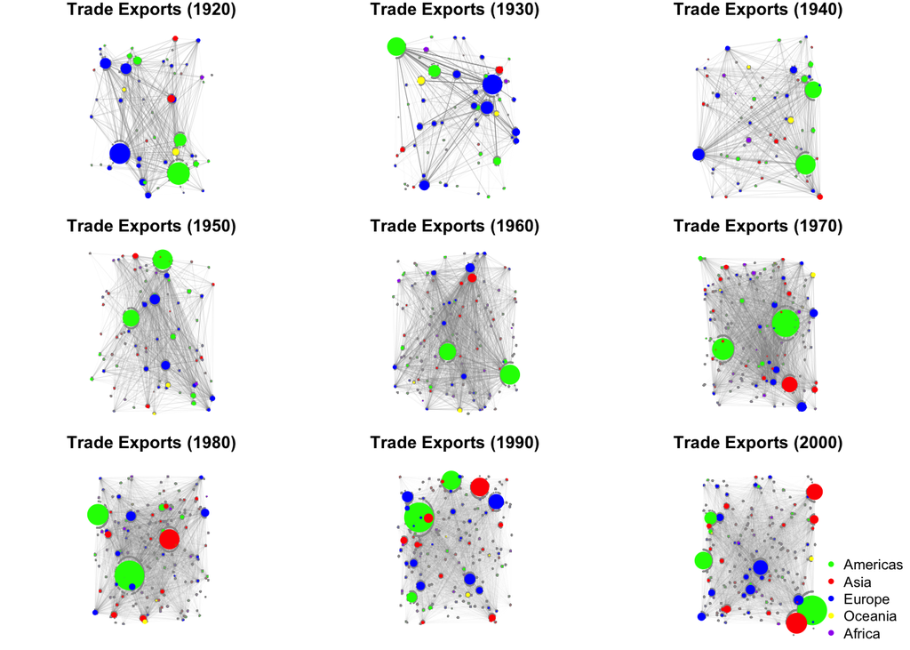

```r
par(mfrow=c(3,3), mar=c(0,0,1,0))
plot(g_1920,
    vertex.label="",
    layout=layout.random,
    vertex.size=V(g_1920)$size,
    #vertex.lab=V(g_1920)$label,
    vertex.color=V(g_1920)$color,
    vertex.frame.color=V(g_1920)$color,
    edge.width=width_1920,
    #edge.curved=.25,
    edge.color="grey60",
    asp=1.3,
    edge.arrow.size=0.02,
    main="Trade Exports (1920)"
)

plot(g_1930,
    vertex.label="",
    layout=layout.random,
    vertex.size=V(g_1930)$size,
    #vertex.lab=V(g_1930)$label,
    vertex.color=V(g_1930)$color,
    vertex.frame.color=V(g_1930)$color,
    edge.width=width_1930,
    #edge.curved=.25,
    edge.color="grey60",
    asp=1.3,
    edge.arrow.size=0.02,
    main="Trade Exports (1930)"
)

plot(g_1940,
    vertex.label="",
    layout=layout.random,
    vertex.size=V(g_1940)$size,
    #vertex.lab=V(g_1940)$label,
    vertex.color=V(g_1940)$color,
    vertex.frame.color=V(g_1940)$color,
    edge.width=width_1940,
    #edge.curved=.25,
    edge.color="grey60",
    asp=1.3,
    edge.arrow.size=0.02,
    main="Trade Exports (1940)"
)

plot(g_1950,
    vertex.label="",
    layout=layout.random,
    vertex.size=V(g_1950)$size,
    #vertex.lab=V(g_1950)$label,
    vertex.color=V(g_1950)$color,
    vertex.frame.color=V(g_1950)$color,
    edge.width=width_1950,
    #edge.curved=.25,
    edge.color="grey60",
    asp=1.3,
    edge.arrow.size=0.02,
    main="Trade Exports (1950)"
)

plot(g_1960,
    vertex.label="",
    layout=layout.random,
    vertex.size=V(g_1960)$size,
    #vertex.lab=V(g_1960)$label,
    vertex.color=V(g_1960)$color,
    vertex.frame.color=V(g_1960)$color,
    edge.width=width_1960,
    #edge.curved=.25,
    edge.color="grey60",
    asp=1.3,
    edge.arrow.size=0.02,
    main="Trade Exports (1960)"
)

plot(g_1970,
    vertex.label="",
    layout=layout.random,
    vertex.size=V(g_1970)$size,
    #vertex.lab=V(g_1970)$label,
    vertex.color=V(g_1970)$color,
    vertex.frame.color=V(g_1970)$color,
    edge.width=width_1970,
    #edge.curved=.25,
    edge.color="grey60",
    asp=1.3,
    edge.arrow.size=0.02,
    main="Trade Exports (1970)"
)

plot(g_1980,
    vertex.label="",
    layout=layout.random,
    vertex.size=V(g_1980)$size,
    #vertex.lab=V(g_1980)$label,
    vertex.color=V(g_1980)$color,
    vertex.frame.color=V(g_1980)$color,
    edge.width=width_1980,
    #edge.curved=.25,
    edge.color="grey60",
    asp=1.3,
    edge.arrow.size=0.02,
    main="Trade Exports (1980)"
)

plot(g_1990,
    vertex.label="",
    layout=layout.random,
    vertex.size=V(g_1990)$size,
    #vertex.lab=V(g_1990)$label,
    vertex.color=V(g_1990)$color,
    vertex.frame.color=V(g_1990)$color,
    edge.width=width_1990,
    #edge.curved=.25,
    edge.color="grey60",
    asp=1.3,
    edge.arrow.size=0.02,
    main="Trade Exports (1990)"
)

plot(g_2000,
    vertex.label="",
    layout=layout.random,
    vertex.size=V(g_2000)$size,
    #vertex.lab=V(g_2000)$label,
    vertex.color=V(g_2000)$color,
    vertex.frame.color=V(g_2000)$color,
    edge.width=width_2000,
    #edge.curved=.25,
    edge.color="grey60",
    asp=1.3,
    edge.arrow.size=0.02,
    main="Trade Exports (2000)"
)

legend('bottomright', legend= c('Americas', 'Asia', 'Europe', 'Oceania', 'Africa'), col = c('green', 'red', 'blue', 'yellow', 'purple'), pch=20, bty = 'n')
```

# Part Three: Descriptive Statistics

First I create vectors of network densities and reciprocity scores. I then use ggplot2 to show the changes over time.

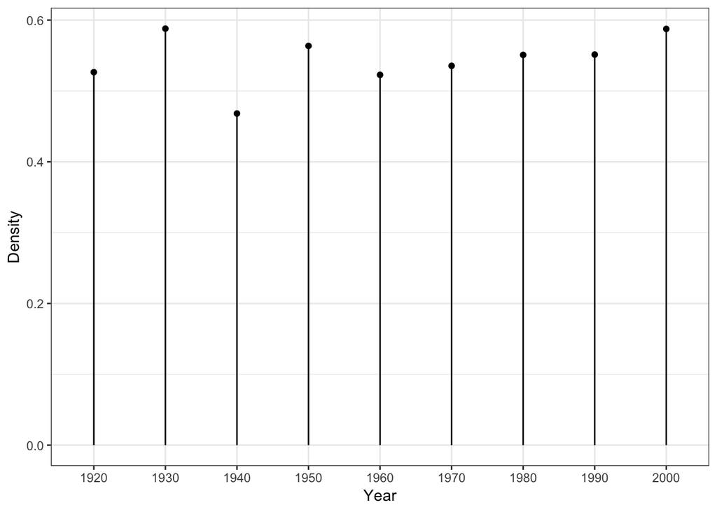

```r
## Density

densities <- c(
                edge_density(g_1920, loops = FALSE),
                edge_density(g_1930, loops = FALSE),
                edge_density(g_1940, loops = FALSE),
                edge_density(g_1950, loops = FALSE),
                edge_density(g_1960, loops = FALSE),
                edge_density(g_1970, loops = FALSE),
                edge_density(g_1980, loops = FALSE),
                edge_density(g_1990, loops = FALSE),
                edge_density(g_2000, loops = FALSE)
            )

names(densities) <- c("1920", "1930", "1940", "1950", "1960", "1970", "1980", "1990", "2000")


# reciprocity measure
recips <- c(
                cor(c(mats[[1]]), c(t(mats[[1]])), use='pairwise.complete.obs'),
                cor(c(mats[[2]]), c(t(mats[[2]])), use='pairwise.complete.obs'),
                cor(c(mats[[3]]), c(t(mats[[3]])), use='pairwise.complete.obs'),
                cor(c(mats[[4]]), c(t(mats[[4]])), use='pairwise.complete.obs'),
                cor(c(mats[[5]]), c(t(mats[[5]])), use='pairwise.complete.obs'),
                cor(c(mats[[6]]), c(t(mats[[6]])), use='pairwise.complete.obs'),
                cor(c(mats[[7]]), c(t(mats[[7]])), use='pairwise.complete.obs'),
                cor(c(mats[[8]]), c(t(mats[[8]])), use='pairwise.complete.obs'),
                cor(c(mats[[9]]), c(t(mats[[9]])), use='pairwise.complete.obs')
            )

names(recips) <- names(densities)

ggdata <- data.frame(density=densities, year=as.numeric(names(densities)))

ggdata$year = factor(ggdata$year, levels=ggdata$year[order(ggdata$year)])

ggplot(data=ggdata, aes(x=year, ymin=0, y=densities, ymax=densities)) +
    geom_linerange() +
    geom_point() +
    ylab('Density') + xlab('Year') +
    theme_bw()
```

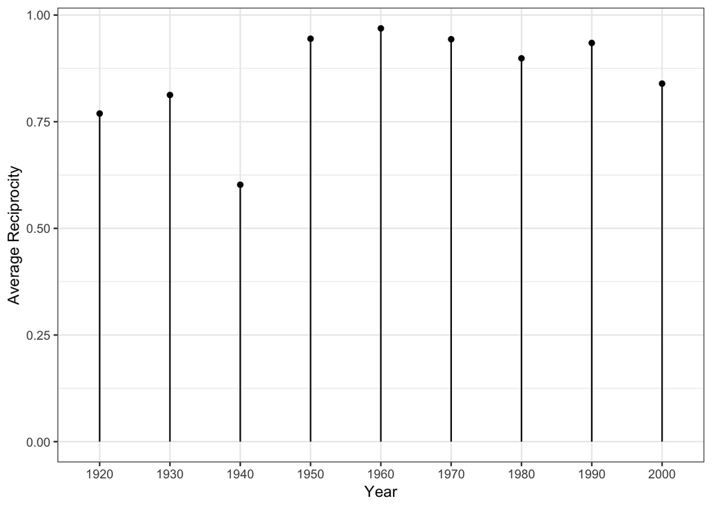

```r
ggdata_recip <- data.frame(recip=recips, year=as.numeric(names(densities)))

ggdata_recip$year = factor(ggdata_recip$year, levels=ggdata_recip$year[order(ggdata_recip$year)])

ggplot(data=ggdata_recip, aes(x=year, ymin=0, y=recips, ymax=recips)) +
    geom_linerange() +
    geom_point() +
    ylab('Average Reciprocity') + xlab('Year') +
    theme_bw()
```

I now calculate the node-level measures, and create a table of the top 30 countries for each.

```r
in_1920 <- sort(degree(g_1920), decreasing=TRUE)
in_2000 <- sort(degree(g_2000), decreasing=TRUE)

out_1920 <- sort(apply(g_1920[], 2, sum), decreasing=TRUE)
out_2000 <- sort(apply(g_2000[], 2, sum), decreasing=TRUE)

total_1920 <- sort(in_1920 + out_1920, decreasing=TRUE)
total_2000 <- sort(in_2000 + out_2000, decreasing=TRUE)

clos_1920 <- sort(closeness(g_1920), decreasing=TRUE)
clos_2000 <- sort(closeness(g_2000), decreasing=TRUE)

bet_1920 <- sort(betweenness(g_1920), decreasing=TRUE)
bet_2000 <- sort(betweenness(g_2000), decreasing=TRUE)

eig_1920 <- sort(eigen_centrality(g_1920)$'vector', decreasing=TRUE)
eig_2000 <- sort(eigen_centrality(g_2000)$'vector', decreasing=TRUE)


top_actors <- data.frame(
            in_degree_1920 = names(in_1920)[1:30],
            out_degree_1920 = names(out_1920)[1:30],
            total_degree_1920 = names(total_1920)[1:30],
            closeness_1920 = names(clos_1920)[1:30],
            betweenness_1920 = names(bet_1920)[1:30],
            eigenvector_1920 = names(eig_1920)[1:30],
            in_degree_2000 = names(in_2000)[1:30],
            out_degree_2000 = names(out_2000)[1:30],
            total_degree_2000 = names(total_2000)[1:30],
            closeness_2000 = names(clos_2000)[1:30],
            betweenness_2000 = names(bet_2000)[1:30],
            eigenvector_2000 = names(eig_2000)[1:30]
    )


# change cow codes back to country names

top_actors <- apply(top_actors, 2, function(x) {
    countrycode(x, origin='cown', destination='country.name')
        }
    )
top_actors <- as.data.frame(top_actors)
stargazer(top_actors[1:6], type='text', summary=FALSE)
```

```
##
## ==========================================================================================================
##    in_degree_1920 out_degree_1920 total_degree_1920   closeness_1920    betweenness_1920  eigenvector_1920
## ----------------------------------------------------------------------------------------------------------
## 1   Netherlands   United Kingdom     Netherlands         Paraguay          Yugoslavia      United States
## 2     Germany      United States       Germany         New Zealand           Latvia        United Kingdom
## 3  United States      Germany       United States        Liberia            Albania            Canada
## 4  United Kingdom     France       United Kingdom       Venezuela            Chile            Germany
## 5      France         Canada           France             Panama              Cuba             France
## 6     Austria       Netherlands        Austria            Poland            Ethiopia         Argentina
## 7      Poland          Italy           Poland             Greece            Bulgaria           Japan
## 8     Belgium         Belgium          Belgium           Hungary             Mexico          Australia
## 9      Italy         Argentina          Italy            Thailand            Panama         Netherlands
## 10   Yugoslavia        Japan         Yugoslavia          Ethiopia          Lithuania          Belgium
## 11     Spain         Australia          Spain          El Salvador          Hungary            Italy
```

[output cut: 20 more lines]

```r
stargazer(top_actors[7:12], type='text', summary=FALSE)
```

```
##
## ================================================================================================================
##    in_degree_2000   out_degree_2000    total_degree_2000  closeness_2000  betweenness_2000    eigenvector_2000
## ----------------------------------------------------------------------------------------------------------------
## 1  United States     United States       United States   Solomon Islands      Zimbabwe         United States
## 2      Canada           Germany             Canada            Nauru            Ecuador             China
## 3  United Kingdom        China          United Kingdom        Brunei           Tuvalu              Canada
## 4     Belgium            Japan              Belgium      Papua New Guinea      Jamaica             Japan
## 5     Germany            France             Germany        Sierra Leone       Maldives            Germany
## 6   Switzerland      United Kingdom       Switzerland         Sweden            Nepal              Mexico
## 7      Poland            Italy              Poland            Gabon            Brunei          United Kingdom
## 8     Hungary         Netherlands           Hungary            Fiji             Peru               France
## 9   Netherlands          Canada           Netherlands      South Africa        Bolivia          South Korea
## 10     France           Belgium             France           Mongolia          Lesotho          Netherlands
## 11     Spain             Spain               Spain             Laos             Nauru              Italy
```

[output cut: 20 more lines]

The top 30 actors for the in/out/total degree measures seem to simply be the richest countries in the world. It makes sense these countries have the most trade. The substnative explanation of the top closeness actors are less clear. These are countries whose total distance to other nodes are lowest. In other words, you do not have to go through many nodes to go from one of these to any other actor. The betweeness scores indicate countries that serve as bridges to other countries. They tend to trade with two groups of countries who do not trade with eachother. Many of these are middle-income countries, who likely trade with both poor and rich countries. Finally, the top eigenvector centrality nodes are very similar to the degree centrality top actors. These are the countries who trade alot with other countries who trade alot. Again, these are the rich countries.

And finally, I create a correlation matrix of the measures.

```r
measures_1920 <- as.data.frame(cbind(in_1920, out_1920, total_1920, clos_1920, bet_1920, eig_1920))

corr_1920 <- as.data.frame(cor(measures_1920))


measures_2000 <- as.data.frame(cbind(in_2000, out_2000, total_2000, clos_2000, bet_2000, eig_2000))

corr_2000 <- as.data.frame(cor(measures_2000))

corr_1920
```

```
##              in_1920  out_1920 total_1920 clos_1920  bet_1920  eig_1920
## in_1920    1.0000000 0.6569441  0.6789272 0.5403159 0.7470965 0.7504802
## out_1920   0.6569441 1.0000000  0.9995637 0.1936203 0.9685890 0.9774794
## total_1920 0.6789272 0.9995637  1.0000000 0.2097210 0.9725068 0.9812970
## clos_1920  0.5403159 0.1936203  0.2097210 1.0000000 0.2128839 0.2242803
## bet_1920   0.7470965 0.9685890  0.9725068 0.2128839 1.0000000 0.9714030
## eig_1920   0.7504802 0.9774794  0.9812970 0.2242803 0.9714030 1.0000000
```

```r
corr_2000
```

```
##              in_2000  out_2000 total_2000 clos_2000  bet_2000  eig_2000
## in_2000    1.0000000 0.4253450  0.4258526 0.9189341 0.5870260 0.4501465
## out_2000   0.4253450 1.0000000  0.9999998 0.6632329 0.9382172 0.9827807
## total_2000 0.4258526 0.9999998  1.0000000 0.6636275 0.9383335 0.9828004
## clos_2000  0.9189341 0.6632329  0.6636275 1.0000000 0.7769010 0.6848655
## bet_2000   0.5870260 0.9382172  0.9383335 0.7769010 1.0000000 0.9617756
## eig_2000   0.4501465 0.9827807  0.9828004 0.6848655 0.9617756 1.0000000
```

# Part Four: Decomposing a matrix

First I recreate the paper visualization, with nodes colored by the averageId.node variable.

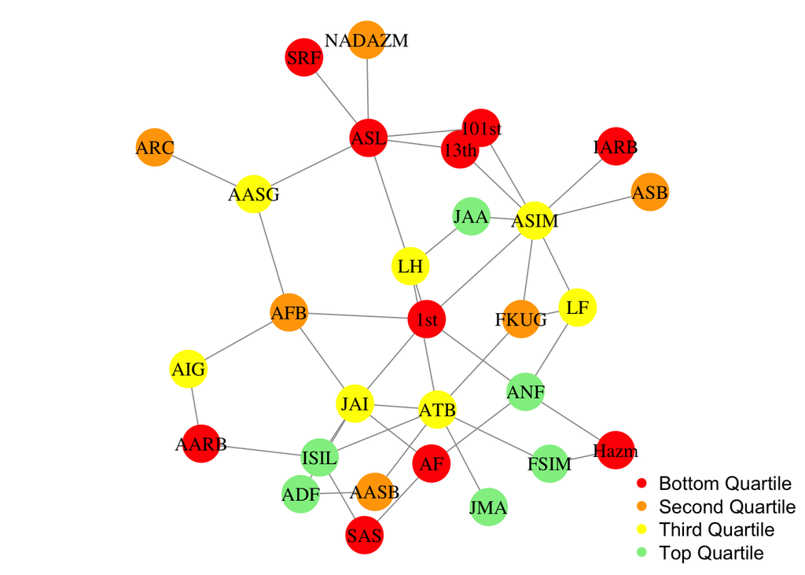

```r
load('gadeData.rda')

library(igraph)

## setup matrix

actors <- unique(c(data$Var1, data$Var2))

n = length(actors)
mat <- matrix(0, nrow=n, ncol=n, dimnames=list(actors,actors))
diag(mat) = NA

data_sub <- data[data$coopActions==1,]

for(i in 1:nrow(data_sub)){
    rowActor = as.character(data_sub$Var1[i])
    colActor = as.character(data_sub$Var2[i])
    mat[rowActor, colActor] = 1
    }


g <- graph_from_adjacency_matrix(mat, mode='undirected', weighted=TRUE, diag=FALSE)

# remove isolates
g_del <- V(g)[strength(g)<=0]
g <- delete.vertices(g, g_del)


## color based on quartiles of AverageId.node
quans <- quantile(data$averageId.node)

# create key of averageId.node
key <- aggregate(data, data[c("Var1", "averageId.node")], length)[,1:2]

# add averageId.node attribute to each node
for(i in V(g)$name) {
    V(g)$color[V(g)$name==i] <- key[key$Var1==i,2]
}

# replace values with colors
V(g)$color[V(g)$color <= quans[2]] <- 'red'
V(g)$color[V(g)$color <= quans[3] & V(g)$color > quans[2]] <- 'orange'
V(g)$color[V(g)$color <= quans[4] & V(g)$color > quans[3]] <- 'yellow'
V(g)$color[V(g)$color > quans[4] & V(g)$color <= quans[5]] <- 'light green'

par(mar=c(0,0,0,0))
plot(g,
    #vertex.size=V(g_bet)$size,
    layout=layout_with_fr,
    #vertex.lab=V(g_bet)$label,
    vertex.color=V(g)$color,
    vertex.frame.color=V(g)$color,
    vertex.label.color="black",
    vertex.label.cex=1,
    #edge.width=width_bet,
    #edge.curved=.25,
    edge.color="grey60",
    #asp=1.3,
    #edge.arrow.size=0.2
)
legend('bottomright', legend= c('Bottom Quartile', 'Second Quartile', 'Third Quartile', 'Top Quartile'), col = c('red', 'orange', 'yellow', 'light green'), pch=19, bty = 'n')
```

Next, I recreate the GLM model, and visualize error by actor

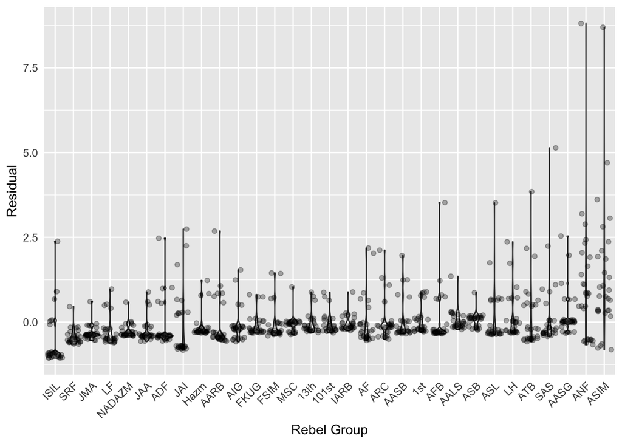

```r
model = glm(coopActions ~
        averageId.node + size.node + spons_actor.node +
        ideol_diff.dyad + powerdiff.dyad + loc.dyad + spons.dyad, family= 'gaussian',
        data=data)

# pull out errors from trade
data$error = model$residuals

# construct sociomatrix out of errors
e = matrix(NA, nrow=n,ncol=n, dimnames=list(actors,actors))

for(ii in 1:nrow(data)){
  e[data$Var1[ii], data$Var2[ii]] = data$error[ii]
}

# visualize pattern
library(reshape2)
library(ggplot2)

errDF = melt(e)
errDF = na.omit(errDF)

# reorder by smallest to largest
row_e = apply(e, 1, mean, na.rm=TRUE)
errDF$Var1 = factor(errDF$Var1, levels=names(sort(row_e)))


ggplot(errDF, aes(x=Var1,y=value)) +
  geom_violin() + geom_jitter(alpha=.3) +
  xlab('Rebel Group') + ylab('Residual') +
  theme(
    axis.ticks=element_blank(),
    panel.border=element_blank(),
    axis.text.x=element_text(angle=45,hjust=1)
    )
```

There does seem to be underlying structure missed by a GLM model, as error do not seem randomly distributed. NEgative residuals are close to zero, while there are extensive positive residuals. Additionally, the final two actors have mich higher average error than the rest of the dataset.